# CALPM

- Show All Code
- Hide All Code
- View Source

Author

Grupa 2

# 1 Pakiety

Pakiety potrzebne do wykonanie analizy danych i modeli.

**Show and hide code**

```r
library(tidymodels)
library(tidyverse)
library(stringr)
library(vip)
library(pdp)
library(DALEX)
library(DALEXtra)
library(bestNormalize)
library(rules)
library(baguette)
library(finetune)
library(doParallel)
library(GGally)
library(openair)
```

# 2 Dane

Załadowanie danych treningowych.

**Show and hide code**

```r
load("dane/ops.RData")
```

## 2.1 Opis danych znajdujących się w zbiorze

**Show and hide code**

```r
ops |> glimpse()
```

```
Rows: 909
Columns: 21
$ date       <dttm> 2022-01-21 11:00:00, 2022-01-21 12:00:00, 2022-01-21 13:00…
$ grimm_pm10 <dbl> 19.4, 12.6, 14.2, 20.3, 13.9, 14.3, 18.1, 22.6, 23.4, 21.9,…
$ ops_pm10   <dbl> 14.745257, 11.785852, 12.404235, 10.295859, 8.731087, 11.21…
$ n_0044     <dbl> 57.314870, 30.484567, 29.523096, 34.837081, 32.161610, 42.7…
$ n_0075     <dbl> 13.583416, 7.921950, 7.318594, 8.273678, 7.905023, 9.997945…
$ n_0100     <dbl> 1.7221058, 1.2214095, 1.0971070, 1.1286867, 1.0181630, 1.12…
$ n_0120     <dbl> 0.3620380, 0.2946828, 0.2770578, 0.2829772, 0.2481288, 0.26…
$ n_0140     <dbl> 0.22770538, 0.19178343, 0.17779177, 0.17846372, 0.15712291,…
$ n_0200     <dbl> 0.4588658, 0.4203183, 0.4098838, 0.3929689, 0.3423779, 0.33…
$ n_0250     <dbl> 0.09386431, 0.09209425, 0.09982402, 0.07900083, 0.06974166,…
$ n_0500     <dbl> 0.13998488, 0.12950709, 0.14115179, 0.10639199, 0.08824277,…
$ n_0750     <dbl> 0.015905973, 0.013818738, 0.014947178, 0.011131220, 0.00803…
$ n_1000     <dbl> 0.0062776549, 0.0046246872, 0.0053611343, 0.0035743675, 0.0…
$ temp       <dbl> -1.341667, -1.626667, -1.960000, -2.001667, -1.488333, -2.1…
$ rh         <dbl> 67.05167, 67.97667, 67.01333, 65.09667, 55.92667, 63.81500,…
$ pres       <dbl> 990.2600, 990.1100, 990.1800, 990.4000, 990.3817, 990.6700,…
$ pres_sea   <dbl> 1016.172, 1016.088, 1016.177, 1016.400, 1016.337, 1016.670,…
$ wd         <dbl> 273, 281, 284, 288, 290, 262, 273, 259, 265, 257, 273, 277,…
$ mws        <dbl> 6.5, 6.5, 6.2, 5.7, 6.4, 4.7, 4.4, 4.7, 3.6, 4.5, 4.3, 4.5,…
$ ws         <dbl> 3.345000, 3.996667, 3.781667, 3.311667, 3.708333, 2.583333,…
$ prec       <dbl> 0, 0, 0, 0, 0, 0, 0, 0, 0, 0, 0, 0, NaN, NaN, NaN, NaN, NaN…
```

Zestaw składa się z 21 zmiennych oraz 909 obserwacji. Objaśnienie każdej z nich:

- `date` - Data (krok 1 godzina)
- `grimm_pm10` - Średnie 1-godzinne stężenie PM10 zmierzone za pomocą GRIMM EDM 180
- `ops_pm10` - Średnie 1-godzinne stężenie PM10 zmierzone za pomocą TSI OPS 3330
- `n_0044` - liczba zliczeń cząstek w od 0.3 do 0.44 µm wyrażona w zliczeniach/cm<sup>3</sup>
- `n_0075` - liczba zliczeń cząstek w od 0.44 do 0.75 µm wyrażona w zliczeniach/cm<sup>3</sup>
- `n_0100` - liczba zliczeń cząstek w od 0.75 do 1.00 µm wyrażona w zliczeniach/cm<sup>3</sup>
- `n_0120` - liczba zliczeń cząstek w od 1.00 do 1.20 µm wyrażona w zliczeniach/cm<sup>3</sup>
- `n_0140` - liczba zliczeń cząstek w od 1.20 do 1.40 µm wyrażona w zliczeniach/cm<sup>3</sup>
- `n_0200` - liczba zliczeń cząstek w od 1.40 do 2.00 µm wyrażona w zliczeniach/cm<sup>3</sup>
- `n_0250` - liczba zliczeń cząstek w od 2.00 do 2.50 µm wyrażona w zliczeniach/cm<sup>3</sup>
- `n_0500` - liczba zliczeń cząstek w od 2.50 do 5.00 µm wyrażona w zliczeniach/cm<sup>3</sup>
- `n_0750` - liczba zliczeń cząstek w od 5.00 do 7.50 µm wyrażona w zliczeniach/cm<sup>3</sup>
- `n_1000` - liczba zliczeń cząstek w od 7.50 do 10.4 µm wyrażona w zliczeniach/cm<sup>3</sup>
- `temp` - temperatura powietrza [°C]
- `rh` - wilgotność względna [%]
- `pres` - ciśnienie na poziomie stacji [hPa]
- `pres_sea` - ciśnienie nad poziomem morza [hPa]
- `wd` - kierunek wiatru [°]
- `mws` - maksymalns prędkość wiatru [m/s]
- `ws` - prędkość wiatru [m/s]
- `prec` - opad atmosferyczny [mm/h]

**Show and hide code**

```r
ops |> is.na() |> colSums()
```

```
      date grimm_pm10   ops_pm10     n_0044     n_0075     n_0100     n_0120
         0          2          0          0          0          0          0
    n_0140     n_0200     n_0250     n_0500     n_0750     n_1000       temp
         0          0          0          0          0          0         48
        rh       pres   pres_sea         wd        mws         ws       prec
        48         48         48         48         48         48         48
```

W zbiorze można zaobserwować liczne braki danych, które należy wyeliminować przed dalszą analizą.

**Show and hide code**

```r
ops <- ops |>
  mutate(across(where(is.numeric), ~ifelse(is.na(.), median(., na.rm = TRUE), .)))

ops |> is.na() |> sum()
```

```
[1] 0
```

Wszystkie braki danych zostały zamienione na mediane z wartości kolumny. Brak danych jakościowych umożliwia wykonanie operacji dla wszystkich atrybutów.

**Show and hide code**

```r
ops |> summary()
```

```
      date                       grimm_pm10        ops_pm10
 Min.   :2022-01-21 11:00:00   Min.   :  2.90   Min.   :  1.624
 1st Qu.:2022-01-30 22:00:00   1st Qu.: 16.10   1st Qu.:  8.325
 Median :2022-02-09 09:00:00   Median : 30.80   Median : 15.886
 Mean   :2022-02-09 09:00:00   Mean   : 41.42   Mean   : 23.470
 3rd Qu.:2022-02-18 20:00:00   3rd Qu.: 58.80   3rd Qu.: 31.719
 Max.   :2022-02-28 07:00:00   Max.   :215.40   Max.   :138.401
     n_0044            n_0075             n_0100             n_0120
 Min.   :  4.178   Min.   :  0.7276   Min.   : 0.08575   Min.   :0.01945
 1st Qu.: 24.951   1st Qu.:  5.9858   1st Qu.: 0.82251   1st Qu.:0.16920
 Median : 58.342   Median : 11.6249   Median : 1.36116   Median :0.29624
 Mean   :101.559   Mean   : 21.2231   Mean   : 1.87321   Mean   :0.36823
 3rd Qu.:132.261   3rd Qu.: 25.8639   3rd Qu.: 2.33044   3rd Qu.:0.47980
 Max.   :765.292   Max.   :215.5690   Max.   :14.40541   Max.   :2.05866
     n_0140            n_0200            n_0250             n_0500
 Min.   :0.01415   Min.   :0.03216   Min.   :0.009057   Min.   :0.01447
 1st Qu.:0.10708   1st Qu.:0.22415   1st Qu.:0.046385   1st Qu.:0.05843
 Median :0.18308   Median :0.37127   Median :0.087110   Median :0.13847
 Mean   :0.21844   Mean   :0.45922   Mean   :0.128823   Mean   :0.23035
 3rd Qu.:0.27291   3rd Qu.:0.57998   3rd Qu.:0.167681   3rd Qu.:0.29201
 Max.   :1.12680   Max.   :1.99174   Max.   :0.807703   Max.   :1.71827
     n_0750              n_1000               temp              rh
 Min.   :0.0006842   Min.   :0.0002004   Min.   :-7.650   Min.   :19.32
 1st Qu.:0.0057798   1st Qu.:0.0021015   1st Qu.: 1.512   1st Qu.:54.05
 Median :0.0160075   Median :0.0054993   Median : 3.188   Median :62.07
 Mean   :0.0302448   Mean   :0.0109251   Mean   : 3.581   Mean   :60.55
 3rd Qu.:0.0388154   3rd Qu.:0.0138654   3rd Qu.: 5.668   3rd Qu.:69.49
 Max.   :0.2584242   Max.   :0.0975555   Max.   :13.985   Max.   :80.52
      pres           pres_sea            wd             mws
 Min.   : 962.0   Min.   : 986.1   Min.   :  1.0   Min.   : 0.600
 1st Qu.: 982.9   1st Qu.:1008.1   1st Qu.:247.0   1st Qu.: 2.600
 Median : 988.7   Median :1014.2   Median :262.0   Median : 4.100
 Mean   : 988.9   Mean   :1014.3   Mean   :252.3   Mean   : 4.308
 3rd Qu.: 996.0   3rd Qu.:1021.6   3rd Qu.:279.0   3rd Qu.: 5.600
 Max.   :1008.5   Max.   :1035.2   Max.   :359.0   Max.   :13.700
       ws              prec
 Min.   :0.3433   Min.   :0.0000
 1st Qu.:1.3200   1st Qu.:0.0000
 Median :2.2900   Median :0.0000
 Mean   :2.4208   Mean   :0.0224
 3rd Qu.:3.2167   3rd Qu.:0.0000
 Max.   :7.2967   Max.   :6.1633
```

Powyżej przedstawiono podsumowanie wszystkich atrybutów zbioru danych.

## 2.2 Zbiór weryfikacyjny i przygotowanie danych do analizy

Dane w zbiorze weryfikacyjnym zawierają analogiczne informacje w stosunku do zestawu danych `ops`, ale pomiary zostały wykonane w innym czasie i miejscu. Ponadto zastosowano inną metodę referencyjną pomiaru stężeń PM10 tj. BAM 1020 Met One Instruments zamiast GRIMM EDM 180.

Załadowanie danych weryfikacyjnych.

**Show and hide code**

```r
load("dane/data_test.rdata")
```

Podgląd danych:

**Show and hide code**

```r
ops_data |> glimpse()
```

```
Rows: 768
Columns: 31
$ date       <dttm> 2022-03-28 11:00:00, 2022-03-28 12:00:00, 2022-03-28 13:00…
$ grimm_pm10 <dbl> 34.6, 35.1, 29.4, 22.8, 25.1, 29.7, 42.2, 48.4, 52.6, 61.9,…
$ n_0044     <dbl> 57.99645, 47.63713, 40.84883, 33.95111, 38.29358, 46.09414,…
$ n_0075     <dbl> 10.321169, 10.248937, 8.701183, 6.582655, 6.873391, 8.03684…
$ n_0100     <dbl> 0.5842989, 0.6181682, 0.5501665, 0.4968869, 0.5224946, 0.63…
$ n_0120     <dbl> 0.10482207, 0.10663098, 0.10668724, 0.09969391, 0.10582430,…
$ n_0140     <dbl> 0.07401362, 0.06804366, 0.06382736, 0.05970559, 0.06256881,…
$ n_0200     <dbl> 0.1526519, 0.1454633, 0.1408482, 0.1285833, 0.1246861, 0.15…
$ n_0250     <dbl> 0.04441785, 0.04681034, 0.04872282, 0.04363414, 0.03833389,…
$ n_0500     <dbl> 0.08141868, 0.08931507, 0.09927356, 0.09005143, 0.07804893,…
$ n_0750     <dbl> 0.012786489, 0.014641268, 0.015748957, 0.015787879, 0.01376…
$ n_1000     <dbl> 0.005569641, 0.006319800, 0.005845149, 0.006928274, 0.00577…
$ ws         <dbl> 3.9316667, 4.0400000, 3.8650000, 3.7033333, 3.5650000, 2.17…
```

[output cut: 18 more lines]

Do analizy zostsną wykorzystane dane od `date` do `prec`, połaczone z danymi ramki danych `bam`.

**Show and hide code**

```r
bam |> tail(5)
```

```
                   date bam_pm10
932 2022-05-05 17:00:00    24.04
933 2022-05-05 18:00:00    23.32
934 2022-05-05 19:00:00    24.20
935 2022-05-05 20:00:00    21.77
936 2022-05-05 21:00:00    20.52
```

Dane będą połączone przy pomocy zmiennej `date` zapobiegając problemowi różnej ilości obserwacji.

Przygotowanie dany:

**Show and hide code**

```r
weryfikacja <- ops_data |> select(date:prec)

weryfikacja <- weryfikacja |>
  left_join(bam, by = "date") |>
  mutate(grimm_pm10 = bam_pm10) |>
  select(-bam_pm10)

ops_pm10 <- ops

ops <- ops |> select(-ops_pm10, -pres_sea)

nazwy <- colnames(ops) |> dput()
```

```
c("date", "grimm_pm10", "n_0044", "n_0075", "n_0100", "n_0120",
"n_0140", "n_0200", "n_0250", "n_0500", "n_0750", "n_1000", "temp",
"rh", "pres", "wd", "mws", "ws", "prec")
```

**Show and hide code**

```r
weryfikacja <- weryfikacja |>
  select(all_of(nazwy))

colnames(weryfikacja) == colnames(ops)
```

```
 [1] TRUE TRUE TRUE TRUE TRUE TRUE TRUE TRUE TRUE TRUE TRUE TRUE TRUE TRUE TRUE
[16] TRUE TRUE TRUE TRUE
```

Poniżej wszystkie aktrybuty danych weryfikacyjnych już z podmienioną kolumną `grimm_pm10` na dane pochodzące z czujnika BAM 1020.

Usunieto dodatkowo braki danych znajdujące się w zbiorze.

**Show and hide code**

```r
weryfikacja <- weryfikacja |> na.omit()

weryfikacja |> glimpse()
```

```
Rows: 532
Columns: 19
$ date       <dttm> 2022-04-02 23:00:00, 2022-04-03 23:00:00, 2022-04-04 23:00…
$ grimm_pm10 <dbl> 24.200, 37.310, 23.770, 15.220, 16.540, 19.410, 26.890, 37.…
$ n_0044     <dbl> 79.348311, 148.498394, 84.410340, 40.485845, 25.096198, 33.…
$ n_0075     <dbl> 11.1086391, 27.3965894, 5.7761276, 5.4314590, 2.4117773, 5.…
$ n_0100     <dbl> 0.8129678, 1.9433236, 0.3641429, 0.3560367, 0.1503589, 0.37…
$ n_0120     <dbl> 0.15018321, 0.31724048, 0.08363293, 0.04527078, 0.03220879,…
$ n_0140     <dbl> 0.08258160, 0.14252738, 0.05750945, 0.01998249, 0.01921879,…
$ n_0200     <dbl> 0.15718404, 0.19437253, 0.09839405, 0.02657826, 0.03799055,…
$ n_0250     <dbl> 0.048222408, 0.033054490, 0.018771413, 0.005608285, 0.00994…
$ n_0500     <dbl> 0.088959967, 0.040607173, 0.022349555, 0.008732555, 0.01646…
$ n_0750     <dbl> 0.0102429803, 0.0038165138, 0.0014582870, 0.0007842647, 0.0…
$ n_1000     <dbl> 0.0022037809, 0.0011531832, 0.0005428254, 0.0001167640, 0.0…
$ temp       <dbl> 0.04333333, 0.21000000, 4.74833333, 7.39000000, 11.54333333…
$ rh         <dbl> 76.87833, 55.84167, 52.55833, 65.63667, 55.62000, 49.11167,…
$ pres       <dbl> 981.6367, 990.3050, 976.5950, 978.0100, 979.6167, 976.2433,…
$ wd         <int> 297, 252, 244, 261, 251, 185, 174, 320, 112, 117, 141, 116,…
$ mws        <dbl> 2.6, 2.9, 7.6, 5.1, 6.4, 1.7, 2.3, 1.0, 1.5, 1.2, 1.2, 1.0,…
$ ws         <dbl> 1.5133333, 1.5183333, 4.9616667, 2.3583333, 3.9666667, 1.13…
$ prec       <dbl> 0.000000000, 0.000000000, 0.000000000, 0.000000000, 0.00000…
```

# 3 Eskploatacyjna analiza danych

Porównanie wyników pomiarowych stężeń PM_10_ wykonanych przy zastowaniu dwóch podobnych metod pomiarowych:

- **TSI OPS 3330** - metoda optyczna nie uznawana za równoważną do referencyjnej
- **GRIMM EDM180** - metoda optyczna równoważna do referencyjnej (kalibrowana na podstawie danych referencyjnych w lokalizacji wykonywania pomiarów)

**Show and hide code**

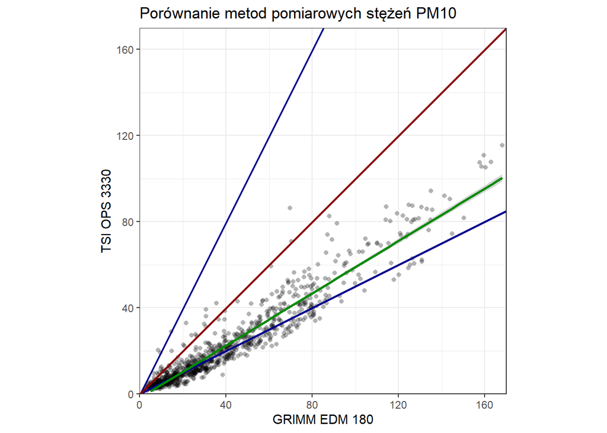

```r
ops_pm10 |> na.omit() |>
  ggplot(mapping = aes(x = grimm_pm10,
                       y = ops_pm10)) +
  geom_point(shape = 16, alpha = 0.3) +
  geom_abline(slope = c(0.5, 2, 1),
              col = c( "blue4", "blue4", "red4"), size = 0.8) +
  geom_smooth(method = lm, color = "green4") +
  theme_bw() +
  scale_x_continuous(expand = c(0,0), limits = c(0, 170)) +
  scale_y_continuous(expand = c(0,0), limits = c(0, 170)) +
  labs(title = "Porównanie metod pomiarowych stężeń PM10",
       y = "TSI OPS 3330",
       x = "GRIMM EDM 180") +
  coord_equal()
```

**Show and hide code**

```r
remove(ops_pm10)
```

Zaobserwowano, że dane z OPS są mocno niedoszacowane względem metody równoważnej do referencyjnej (około 2 krotnie).

## 3.1 Szereg czasowy danych

**Show and hide code**

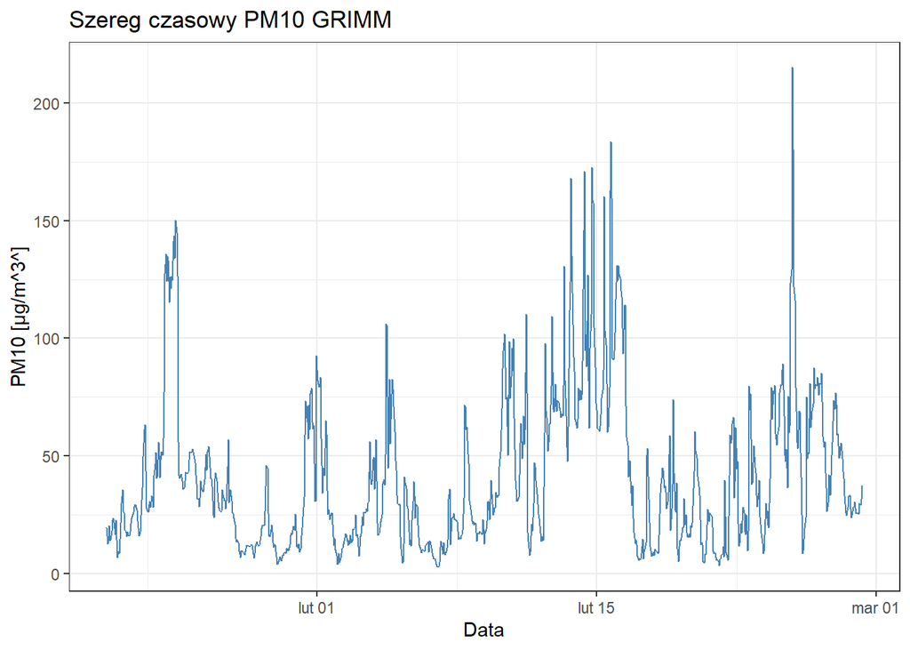

```r
ops |>
  ggplot(aes(x = date, y = grimm_pm10)) +
  geom_line(color = "steelblue") +
  theme_bw() +
  labs(title = "Szereg czasowy PM10 GRIMM",
       x = "Data",
       y = "PM10 [µg/m^3^]")
```

W szeregu czasowym można zauważyć znaczną zmienność poziomu stężenia pyłu zawieszonego. Dane wykazują także wyraźny charakter cykliczny, w niektórych dniach obserwuje się zauważalne spadki stężenia w porównaniu z okresami, w których jego poziom jest najwyższy.

## 3.2 PM10 vs dni tygodnia

Dodanie rozróżnienia w dniach tygodnia

**Show and hide code**

```r
ops <-
  ops |>
  janitor::clean_names() |>
  mutate(jday = lubridate::yday(date)) |>
  mutate(
    wday = lubridate::wday(x = date, abbr = T, label = T),
    hour = lubridate::hour(x = date),
    day_work = case_when(
      wday %in% c("Mon", "Tue", "Wed", "Thu", "Fri") ~ "week",
      wday %in% c("Sat", "Sun") ~ "weekend"
    )
  ) |>
  mutate(day_work = as.factor(day_work))

weryfikacja <-
  weryfikacja |>
  janitor::clean_names() |>
  mutate(jday = lubridate::yday(date)) |>
  mutate(
    wday = lubridate::wday(x = date, abbr = T, label = T),
    hour = lubridate::hour(x = date),
    day_work = case_when(
      wday %in% c("Mon", "Tue", "Wed", "Thu", "Fri") ~ "week",
      wday %in% c("Sat", "Sun") ~ "weekend"
    )
  ) |>
  mutate(day_work = as.factor(day_work))
```

Wykres pokazujący średnie wartości stężenia PM10 w danym dniu tygodnia.

**Show and hide code**

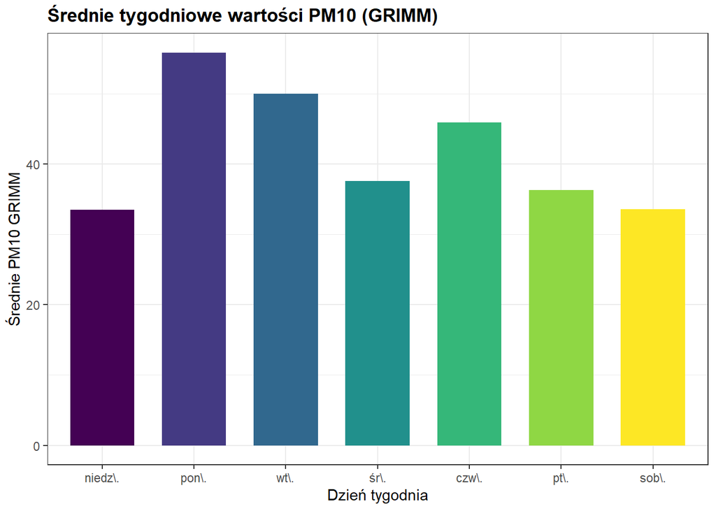

```r
ops |>
  group_by(wday) |>
  summarise(mean_pm10 = mean(grimm_pm10, na.rm = TRUE)) |>
  ggplot(aes(x = wday, y = mean_pm10, fill = wday)) +
  geom_col(width = 0.7) +
  scale_fill_viridis_d(option = "D") +
  labs(title = "Średnie tygodniowe wartości PM10 (GRIMM)",
      x = "Dzień tygodnia",
      y = "Średnie PM10 GRIMM",
      fill = "Dzień tygodnia") +
  theme_bw() +
  theme(legend.position = "none",
        plot.title = element_text(face = "bold"))
```

## 3.3 Wizualizacja zliczeń w czasie

Przedstawienie danych, które zostaną użyte w modelach ml.

**Show and hide code**

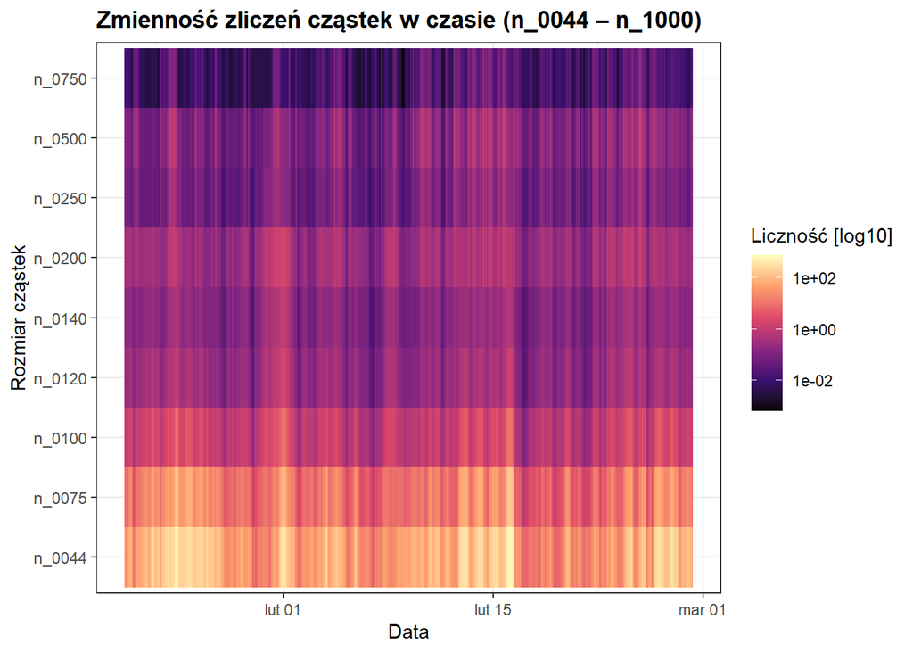

```r
ops |>
  select(date, starts_with("n_0")) |>
  pivot_longer(cols = starts_with("n_0"),
               names_to = "particle_size",
               values_to = "count") |>
  mutate(particle_size = factor(particle_size,
                                levels = c("n_0044", "n_0075", "n_0100",
                                           "n_0120", "n_0140", "n_0200",
                                           "n_0250", "n_0500", "n_0750",
                                           "n_1000"))) |>
  ggplot(aes(x = date, y = particle_size, fill = count)) +
  geom_tile() +
  scale_fill_viridis_c(option = "magma", trans = "log10") +
  labs(title = "Zmienność zliczeń cząstek w czasie (n_0044 – n_1000)",
       x = "Data",
       y = "Rozmiar cząstek",
       fill = "Liczność [log10]") +
  theme_bw()+
  theme(axis.text.y = element_text(size = 9),
        plot.title = element_text(face = "bold"))
```

## 3.4 Korelacje między zmiennymi

**Show and hide code**

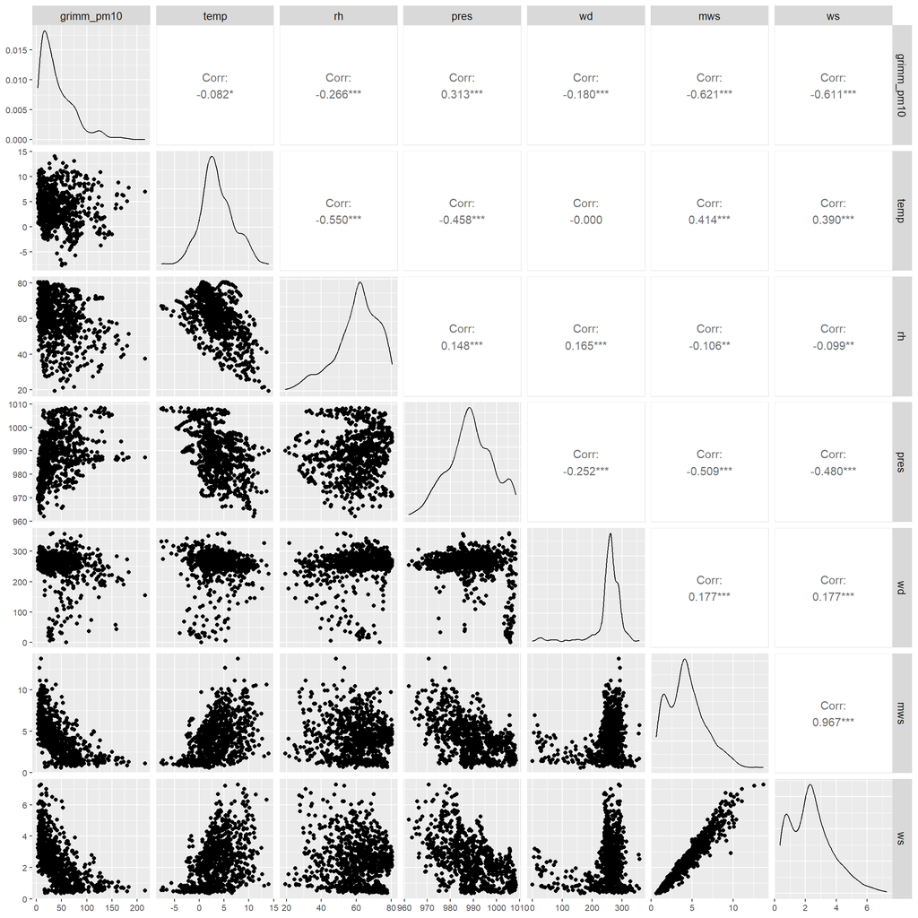

```r
ops |>
  select(grimm_pm10, temp, rh, pres, wd, mws, ws) |>
  ggpairs() +
  theme(axis.text = element_text(size = 8),
        strip.text = element_text(size =10))
```

# 4 Podział danych

**Show and hide code**

```r
set.seed(423)

data_split <- initial_validation_split(data = ops)

ops_train <- training(data_split)
ops_test <- testing(data_split)
ops_valid <- validation_set(data_split)

save(data_split, ops_train, ops_test, ops_valid, weryfikacja, file = "spliting_ops.Rdata")
```

Dane zostały podzielone na odpowiednie grupy w celu wukonanie modeli uczenia maszynowego. Jako zbiór weryfikacyjny `weryfikacja`.

# 5 Tworzenie recept

**Show and hide code**

```r
base_recipe <- recipe(grimm_pm10 ~ ., data = ops_train) |>
  step_rm(date) |>
  step_mutate(
    hour_sin = sin(2 * pi * hour / 24),
    hour_cos = cos(2 * pi * hour / 24)
  ) |>
  step_rm(hour) |>
  step_mutate(
    wd_sin = sin(wd * pi / 180),
    wd_cos = cos(wd * pi / 180)
  ) |>
  step_rm(wd) |>
  step_unknown(day_work) |>
  step_zv(all_predictors()) |>
  step_dummy(all_nominal_predictors(), one_hot = TRUE, sparse = NULL) |>
  step_zv(all_predictors())


recipe_linear <- base_recipe |>
  step_normalize(all_numeric_predictors()) |>
  step_corr(all_numeric_predictors(), threshold = 0.9)

recipe_tree <- base_recipe
```

# 6 Definicja modeli

**Show and hide code**

```r
# 1. Linear model
lm_spec <- linear_reg() |>
  set_engine("lm")

# 2. Elastic Net (GLMNet)
glmnet_spec <- linear_reg(
  penalty = tune(),
  mixture = tune()
) |>
  set_engine("glmnet")

# 3. Random Forest
rf_spec <- rand_forest(
  mtry = tune(),
  trees = tune(),
  min_n = tune()
) |>
  set_engine("ranger", importance = "impurity") |>
  set_mode("regression")

# 4. XGBoost
xgb_spec <- boost_tree(
  trees = tune(),
  learn_rate = tune(),
  tree_depth = tune(),
  loss_reduction = tune(),
  min_n = tune()
) |>
  set_engine("xgboost") |>
  set_mode("regression")
```

# 7 Workflow modeli

**Show and hide code**

```r
lm_wf     <- workflow() |> add_model(lm_spec) |> add_recipe(recipe_linear)
glmnet_wf <- workflow() |> add_model(glmnet_spec) |> add_recipe(recipe_linear)
rf_wf     <- workflow() |> add_model(rf_spec) |> add_recipe(recipe_tree)
xgb_wf    <- workflow() |> add_model(xgb_spec) |> add_recipe(recipe_tree)
```

# 8 Walidacja i metryki

**Show and hide code**

```r
set.seed(123)
folds <- vfold_cv(ops_train, v = 5)

custom_metrics <- metric_set(rmse, mae, mape, rsq)
```

# 9 Siatki parametrów

**Show and hide code**

```r
glmnet_grid <- grid_regular(
  penalty(range = c(-4, 0)),
  mixture(range = c(0, 1)),
  levels = 6
)

rf_grid <- grid_regular(
  mtry(range = c(3, 10)),
  trees(range = c(300, 1000)),
  min_n(range = c(2, 10)),
  levels = 4
)

xgb_grid <- grid_regular(
  trees(range = c(500, 1500)),
  learn_rate(range = c(-3, -1)),
  tree_depth(range = c(2, 8)),
  loss_reduction(),
  min_n(),
  levels = 3
)
```

**Show and hide code**

```r
save_file <- "model_results.RData"

if (!file.exists(save_file)) {
  registerDoParallel()

  # LM (bez tuningu)
  lm_res <- fit_resamples(
    lm_wf,
    resamples = folds,
    metrics = custom_metrics
  )

  # Pozostałe modele z tuningiem
  glmnet_res <- tune_grid(
    glmnet_wf,
    resamples = folds,
    grid = glmnet_grid,
    metrics = custom_metrics
  )

  rf_res <- tune_grid(
    rf_wf,
    resamples = folds,
    grid = rf_grid,
    metrics = custom_metrics
  )

  xgb_res <- tune_grid(
    xgb_wf,
    resamples = folds,
    grid = xgb_grid,
    metrics = custom_metrics
  )

  # Zapis wyników do pliku .RData
  save(lm_res, glmnet_res, rf_res, xgb_res, file = save_file)

  cat("Wyniki zapisane do", save_file, "\n")

} else {
  cat("Plik", save_file, "już istnieje. Nie zapisano nowych wyników.\n")
  load(save_file)
}
```

```
Plik model_results.RData już istnieje. Nie zapisano nowych wyników.
```

# 10 Porównanie wyników

**Show and hide code**

```r
results <- bind_rows(
  collect_metrics(lm_res) |> mutate(model = "lm"),
  collect_metrics(glmnet_res) |> mutate(model = "glmnet"),
  collect_metrics(rf_res) |> mutate(model = "rf"),
  collect_metrics(xgb_res) |> mutate(model = "xgb")
)

results_summary <- results |>
  filter(.metric %in% c("rmse", "mae", "mape", "rsq")) |>
  group_by(model, .metric) |>
  summarise(mean = mean(mean), .groups = "drop") |>
  pivot_wider(names_from = .metric, values_from = mean) |>
  arrange(rmse)

results_summary
```

```
# A tibble: 4 × 5
  model    mae  mape  rmse   rsq
  <chr>  <dbl> <dbl> <dbl> <dbl>
1 lm      5.59  21.6  7.76 0.948
2 glmnet  5.71  22.1  7.82 0.948
3 rf      5.23  17.0  8.29 0.947
4 xgb     9.38  23.7 14.4  0.914
```

# 11 Wybór najlepszego

**Show and hide code**

```r
# Lista modeli i workflow
models <- list(
  lm = lm_wf,
  glmnet = glmnet_wf,
  rf = rf_wf,
  xgb = xgb_wf
)

# Lista wyników resampling / tuning
resamples_list <- list(
  lm = lm_res,       # brak tuningu
  glmnet = glmnet_res,
  rf = rf_res,
  xgb = xgb_res
)

# Lista do przechowywania finalnych workflow
final_workflows <- list()

# Funkcja do finalizacji i last_fit
fit_and_collect <- function(model_name, wf, res) {
  if (model_name %in% c("lm")) {
    # brak tuningu, używamy od razu workflow
    final_wf <- wf
  } else {
    # wybór najlepszego zestawu parametrów wg RMSE
    best_params <- select_best(res, metric = "rmse")
    final_wf <- finalize_workflow(wf, best_params)
  }

  # zapisujemy finalny workflow w liście globalnej
  final_workflows[[model_name]] <<- final_wf

  # last_fit na podziale danych
  final_fit <- last_fit(final_wf, split = data_split, metrics = custom_metrics)

  # zbierz metryki
  metrics <- collect_metrics(final_fit) |>
    mutate(model = model_name)

  return(metrics)
}

# Iteracja po wszystkich modelach
all_metrics <- map2_dfr(models, names(models), ~fit_and_collect(.y, .x, resamples_list[[.y]]))

# Tabela szeroka
metrics_table <- all_metrics |>
  select(model, .metric, .estimate) |>
  pivot_wider(
    names_from = .metric,
    values_from = .estimate
  ) |>
  arrange(rmse)

# Wyświetlenie wyników
metrics_table
```

```
# A tibble: 4 × 5
  model   rmse   mae  mape   rsq
  <chr>  <dbl> <dbl> <dbl> <dbl>
1 xgb     5.60  3.64  12.5 0.969
2 rf      6.85  4.09  13.2 0.952
3 glmnet  6.90  5.02  19.8 0.952
4 lm      6.94  5.02  19.4 0.952
```

# 12 Weryfikacja na danych zewnętrznych

**Show and hide code**

```r
final_fitted <- map(final_workflows, ~fit(.x, data = training(data_split)))
custom_metrics <- metric_set(rmse, mae, rsq, mape)

compute_metrics <- function(model_name, wf) {
  preds <- augment(wf, new_data = weryfikacja) |>
    rename(.pred = .pred)

  metrics <- custom_metrics(preds, truth = grimm_pm10, estimate = .pred) |>
    mutate(model = model_name)

  return(metrics)
}

# iteracja po wszystkich modelach
verification_metrics <- map2_dfr(names(final_fitted), final_fitted, compute_metrics)

# pivot
metrics_table_verif <- verification_metrics |>
  select(model, .metric, .estimate) |>
  pivot_wider(names_from = .metric, values_from = .estimate) |>
  arrange(rmse)

metrics_table_verif
```

```
# A tibble: 4 × 5
  model   rmse   mae   rsq  mape
  <chr>  <dbl> <dbl> <dbl> <dbl>
1 rf      6.57  5.33 0.888  19.1
2 xgb     7.54  6.19 0.878  23.0
3 glmnet 12.6  10.8  0.813  45.9
4 lm     13.2  11.2  0.789  46.6
```